# Project: Classification, Regression and Predicting high site traffic

2025-01-04

**Author:**

- ADOUSSINGANDE Céline
- BOULANKI Loukmane
- COULIBALY Djeneba

# 1 Preliminaries: The site traffic data

The data are from a website for cooking recipes. The company that owns the website wants to sell subscriptions, and the idea is that if the website receives lots of visits (so traffic is “high”) because of a posted recipe, the likelihood of a subscription sale increases.

Hence the overall objective of this project is to predict which recipes will lead to high traffic.

The raw data set for this project is “recipe_site_traffic_2212.csv”.

| Variable | Explanation |
| --- | --- |
| recipe | unique identifier of recipe |
| calories | number of calories |
| carbohydrate | amount of carbohydrates in grams |
| sugar | amount of sugar in grams |
| protein | amount of protein in grams |
| category | type of recipe. Recipes are listed in one of ten possible groupings (Lunch/Snacks’, ‘Beverages’, ‘Potato’, ‘Vegetable’, ‘Meat’, ‘Chicken, ’Pork’, ‘Dessert’, ‘Breakfast’, ‘One Dish Meal’). |
| servings | number of servings for the recipe |
| high_traffic | if the traffic to the site was high when this recipe was shown, this is marked with “High”. |

## Library

```r
library(tidyverse)
library(ggplot2)
library(dplyr)
library(caret)
library(stargazer)
library(gridExtra)
library(randomForest)
library(pROC)
```

## Importing the database

```r
traffic <- read_csv("data/recipe_site_traffic_2212.csv")
glimpse(traffic)
```

```
Rows: 947
Columns: 8
$ recipe       <chr> "001", "002", "003", "004", "005", "006", "007", "…
$ calories     <dbl> NA, 35.48, 914.28, 97.03, 27.05, 691.15, 183.94, 2…
$ carbohydrate <dbl> NA, 38.56, 42.68, 30.56, 1.85, 3.46, 47.95, 3.17, …
$ sugar        <dbl> NA, 0.66, 3.09, 38.63, 0.80, 1.65, 9.75, 0.40, 3.3…
$ protein      <dbl> NA, 0.92, 2.88, 0.02, 0.53, 53.93, 46.71, 32.40, 3…
$ category     <chr> "Pork", "Potato", "Breakfast", "Beverages", "Bever…
$ servings     <chr> "6", "4", "1", "4", "4", "2", "4", "4", "6", "2", …
$ high_traffic <chr> "High", "High", NA, "High", NA, "High", NA, NA, "H…
```

For instance, a data row codes a recipe, say for “tomato soup” as: the number of servings, the category, and the nutritional breakdown. Not recorded are, for instance, the actual cooking ingredients necessary for the recipe, or the required preparation time. The response variable is indicating whether this recipe generated low or high site traffic / number of visits on the website.high_traffic.

# 2 The tasks

## 1- Data wrangling

Specifically, it will be a question of recoding the high_traffic variable and dealing with the missing values.

### a- Recoding of variables and validity of the data.

#### - Recoding the high_traffic variable

```r
traffic$high_traffic <- ifelse(is.na(traffic$high_traffic), 0,
  ifelse(traffic$high_traffic == "High", 1, 0))
head(traffic,2)
```

| recipe | calories | carbohydrate | sugar | protein | category | servings | high_traffic |
| --- | --- | --- | --- | --- | --- | --- | --- |
| 001 | NA | NA | NA | NA | Pork | 6 | 1 |
| 002 | 35.48 | 38.56 | 0.66 | 0.92 | Potato | 4 | 1 |

```r
NA
```

Our variable high-traffic includes a “High” category and missing values (Na).

Indeed, the high-traffic variable takes the value 1 for all recipes with high traffic (“High”) and 0 otherwise (represented in our case by Na when the recipes are not visited at all or are less visited on the site).

#### - Validity of the data

The high_traffic variable becomes a binary numeric variable, taking the value 1 for high-traffic recipes and 0 for the others. This binary structure is particularly suitable for our analysis objectives, especially for the application of the different predicted models (Linear Probability Model, Logit Model and Random Forest Model). These models require a binary dependent variable, which fully justifies the validity of our data.

### b- Missing Value Management

```r
traffic %>%
  summarise(across(everything() , ~ mean(is.na(.x) ) ) ) %>%
  select(where(~ .x > 0))
```

| calories | carbohydrate | sugar | protein |
| --- | --- | --- | --- |
| 0.05491024 | 0.05491024 | 0.05491024 | 0.05491024 |

The calorie, carbohydrate, sugar and protein variables have the same number of missing values, i.e. 5.49% of missing values, and those for the same individuals. In this specific case, we can delete observations with missing values in the database.

```r
traffic <- drop_na(traffic)
colSums(is.na(traffic))
```

```
      recipe     calories carbohydrate        sugar      protein
           0            0            0            0            0
    category     servings high_traffic
           0            0            0
```

Removing missing values does not distort the results in that they represent a small percentage (5.49%). The current number of sightings is 895 out of the 947.

## 2- Exploratory Data Analysis (EDA)

Before we vigorously embark on the analysis of our data, we will first convert the categorical variables into a factor and then explore the relationships between our dependent variable ( high_trafic ) with the other variables in the database.

### a- Conversion of the categorical variables “category” and “servings” into a factor

```r
traffic <- traffic%>%
  mutate_if(is.character, as.factor) %>%
  mutate(category = factor(category))%>%
  mutate(servings = factor(servings))

str(traffic)
```

[output not shown]

### b- Exploration of the relationships between high_trafic with the other variables .

```r
traffic %>%
  count(high_traffic) %>%
  mutate(prop = n/sum(n))
```

| high_traffic | n | prop |
| --- | --- | --- |
| 0 | 360 | 0.4022346 |
| 1 | 535 | 0.5977654 |

The analysis of these results shows that more than half of the revenues, i.e. (59.77%), have a high traffic .

#### - Grouping by category of receipts with high traffic

```r
traffic %>%
    group_by(category) %>%
    summarise(mean_trafic = mean(high_traffic))
```

| category | mean_trafic |
| --- | --- |
| Beverages | 0.05434783 |
| Breakfast | 0.31132075 |
| Chicken | 0.36231884 |
| Chicken Breast | 0.46808511 |
| Dessert | 0.62337662 |
| Lunch/Snacks | 0.63414634 |
| Meat | 0.75675676 |
| One Dish Meal | 0.76119403 |
| Pork | 0.90410959 |
| Potato | 0.93975904 |

[output cut: 1 more lines]

```r
NA
```

#### - Grouping by servings of receipts with high traffic

```r
traffic %>%
    group_by(servings) %>%
    summarise(mean_trafic = mean(high_traffic))
```

| servings | mean_trafic |
| --- | --- |
| 1 | 0.5857988 |
| 2 | 0.5632184 |
| 4 | 0.6000000 |
| 4 as a snack | 0.5000000 |
| 6 | 0.6358696 |
| 6 as a snack | 1.0000000 |

This table shows the average values of the high_traffic variable (indicating high traffic) for each group of the servings variable. For example, the average probability of high traffic for revenue with 1 portion is 58.58%. This suggests that a recipe with a single serving is moderately associated with high traffic.

Thus, serving6 recipes as snacks seem to have the greatest ability to generate high traffic. Recipes with 1, 2, and 4 servings generate moderate traffic, while 4-serving “snacks” perform worse.

#### - Grouping by category and by servings of receipts with high traffic.

```r
traffic %>%
    group_by(category,servings) %>%
    summarise(mean_trafic = mean(high_traffic))
```

| category | servings | mean_trafic |
| --- | --- | --- |
| Beverages | 1 | 0.05000000 |
| Beverages | 2 | 0.05882353 |
| Beverages | 4 | 0.02941176 |
| Beverages | 6 | 0.09523810 |
| Breakfast | 1 | 0.34615385 |
| Breakfast | 2 | 0.33333333 |
| Breakfast | 4 | 0.21951220 |
| Breakfast | 6 | 0.44444444 |
| Chicken | 1 | 0.46666667 |
| Chicken | 2 | 0.23076923 |

[output cut: 36 more lines]

```r
NA
```

### c- Visualisation

#### - Categorical variables

- Relationships between category and high_traffic

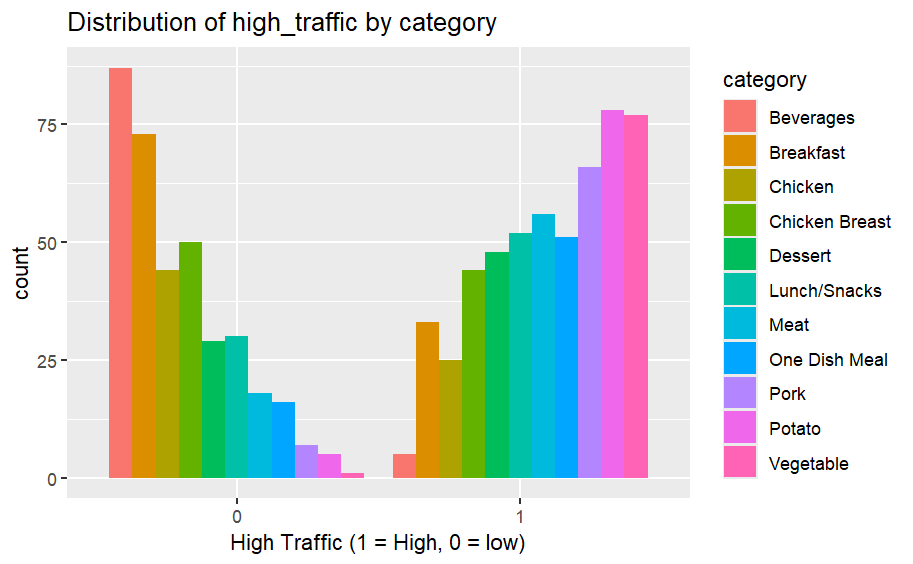

- Relationships between servings and high_traffic

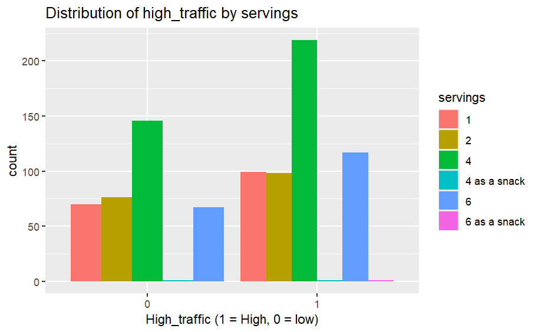

- Relationship between high traffic, category and servings

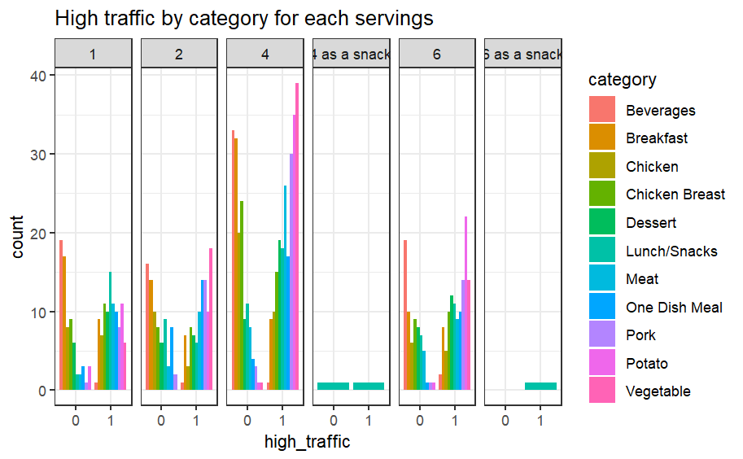

```r
ggplot(traffic %>% mutate(high_traffic = factor(high_traffic)), aes(x=high_traffic, fill=category)) +
    geom_bar(position="dodge") +
    facet_grid(~ servings) +
    labs(title="High traffic by category for each servings") +
    theme_bw()
```

#### - Numerical variables

- Relationships between calories and high_traffic

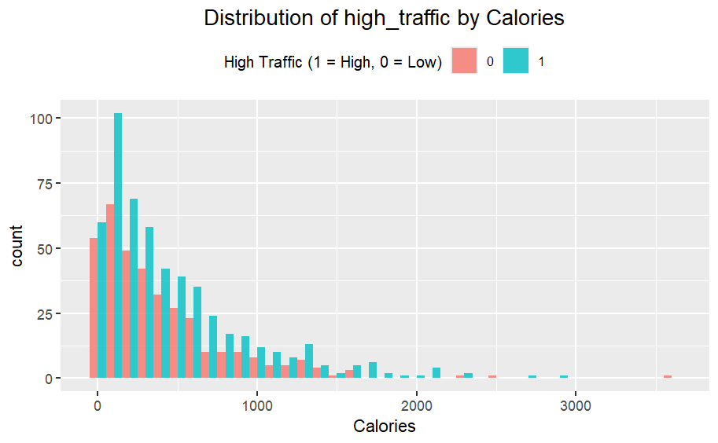

- Relationships between carbohydrate and high_traffic

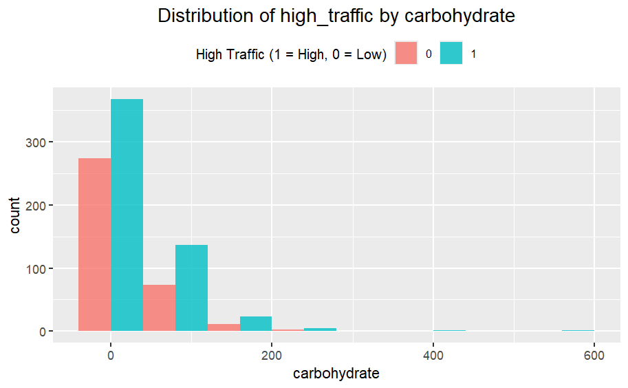

Low carbohydrate recipes (0-100 g) attract more high traffic, while high carbohydrate recipes (>100 g) attract less high traffic.

- Relationships between sugar and high_traffic

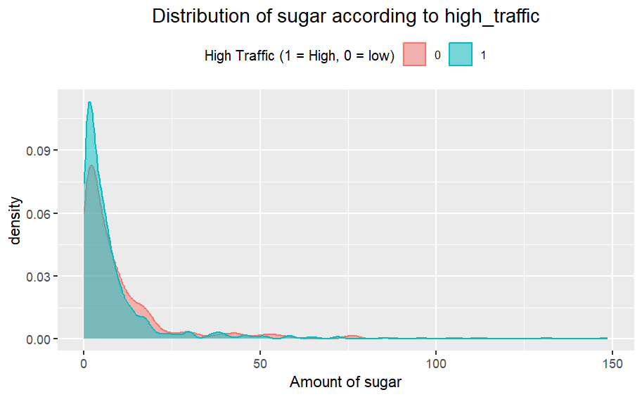

Low sugar recipes (0-20 g) attract more high traffic, while high sugar recipes (>20 g) attract less high traffic.

- Relationships between protein and high_traffic

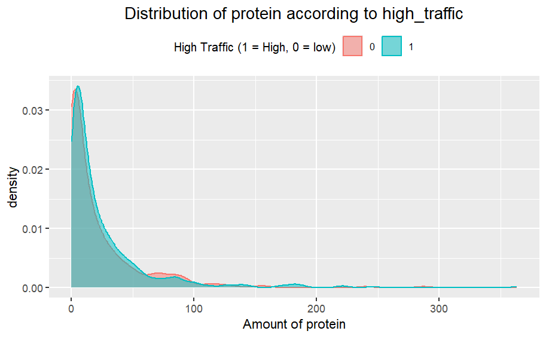

## 3- Split the data into training and test set.

This section consists of dividing our database into test data and training data in order to evaluate the predictability performance of our model. To do this, we will put 60% of the observations in the training base and the remaining 40% in the test data.

### - Division of data in training and test sets

Our database is divided into 60% training and 40% testing because our results require a richer test set and also to give more weight to the evaluation of our models.

```r
set.seed(123)  # For reproducibility

# Divide the data into 60% training and 40% test
traffic_split <- createDataPartition(traffic$high_traffic, p = 0.6, list = FALSE)
traffic_train <- traffic[traffic_split, ]
traffic_test <- traffic[-traffic_split, ]

# Check the dimensions of the sets
dim(traffic_train)
```

```
[1] 537   8
```

```r
dim(traffic_test)
```

```
[1] 358   8
```

### - cross-validation

```r
control <- trainControl(method = "cv", number = 10)
```

## 4.Estimation of the Linear Probability Model (LPM) and the Logit Model

### - LPM Model

The outcome of interest is a category (High traffic or not). Since Y is binary (0/1), the linear model **E(Y|X=x)** therefore is a model for the probability of high traffic. If our model is **E(Y|X=x)=Pr{Y=1|X=x}=βx**, we model this probability as a linear index βx. This is the linear probability model (LPM).

```r
model <- high_traffic ~ category + calories + carbohydrate + sugar + protein + servings

lpm_model <- lm(model, data = traffic_train)
```

### - Logit Model

This discrete response model is:

**E{Y|X=x}=Pr{Y=1|X=x}=G(βx)**

where G is the logistic distribution **G(z)=exp(z)/(1+exp(x))**

```r
logit_model <- glm(model, data = traffic_train, family="binomial")
```

### - The summary of the model with stargazer

```r
stargazer(lpm_model, logit_model, type = "text", title = "Résult of the regression model",
          align = TRUE, digits = 3,
          column.labels=c("LPM ", "LOGIT"),
          header=FALSE,
          dep.var.caption="",dep.var.labels="",
          omit.table.layout = "n", star.cutoffs = NA,no.space=TRUE,
          keep.stat=c("rsq","n"))
```

```
Résult of the regression model
==========================================

                          OLS    logistic
                          LPM      LOGIT
                          (1)       (2)
------------------------------------------
categoryBreakfast        0.244     2.118
                        (0.080)   (0.778)
categoryChicken          0.307     2.343
                        (0.089)   (0.804)
categoryChicken Breast   0.349     2.510
                        (0.087)   (0.793)
categoryDessert          0.619     3.760
                        (0.095)   (0.829)
categoryLunch/Snacks     0.625     3.747
                        (0.091)   (0.814)
categoryMeat             0.646     3.851
                        (0.090)   (0.819)
categoryOne Dish Meal    0.609     3.670
                        (0.098)   (0.840)
categoryPork             0.811     5.137
                        (0.091)   (0.911)
categoryPotato           0.884     6.112
                        (0.086)   (1.033)
categoryVegetable        0.918     6.867
                        (0.086)   (1.248)
calories               -0.00000   0.00000
                       (0.00004) (0.0003)
carbohydrate           -0.00001   -0.0001
                       (0.0005)   (0.003)
sugar                   -0.002    -0.010
                        (0.002)   (0.009)
protein                  0.001     0.007
                        (0.001)   (0.004)
servings2               -0.079    -0.489
                        (0.058)   (0.352)
servings4               -0.009    -0.025
                        (0.051)   (0.310)
servings4 as a snack     0.260    13.485
                        (0.412)  (882.744)
servings6               -0.009    -0.006
                        (0.058)   (0.356)
servings6 as a snack     0.260    13.483
                        (0.411)  (882.744)
Constant                 0.091    -2.820
                        (0.075)   (0.766)
------------------------------------------
Observations              537       537
R2                       0.339
==========================================
```

### a- Comparison of the marginal effects of the two models.

#### - Logit model

```r
me_logit_atmean <- mfx::logitmfx(model, data=traffic_train, atmean = TRUE)
me_logit_atmean
```

```
Call:
mfx::logitmfx(formula = model, data = traffic_train, atmean = TRUE)

Marginal Effects:
                             dF/dx   Std. Err.       z  P>|z|
categoryBreakfast       3.0338e-01  4.0589e-01  0.7474 0.4548
categoryChicken         3.0453e-01  4.2639e-01  0.7142 0.4751
categoryChicken Breast  3.2444e-01  4.4572e-01  0.7279 0.4667
categoryDessert         3.6985e-01  5.1962e-01  0.7118 0.4766
categoryLunch/Snacks    3.6014e-01  5.1466e-01  0.6998 0.4841
categoryMeat            3.7290e-01  5.2310e-01  0.7129 0.4759
categoryOne Dish Meal   3.4581e-01  5.0527e-01  0.6844 0.4937
categoryPork            4.0271e-01  5.5354e-01  0.7275 0.4669
categoryPotato          4.4437e-01  5.7211e-01  0.7767 0.4373
categoryVegetable       4.5389e-01  5.7593e-01  0.7881 0.4306
calories                4.9467e-08  5.4281e-05  0.0009 0.9993
carbohydrate           -2.9131e-05  6.1635e-04 -0.0473 0.9623
sugar                  -2.1421e-03  2.6543e-03 -0.8070 0.4196
protein                 1.5129e-03  1.5470e-03  0.9780 0.3281
servings2              -1.0926e-01  1.1466e-01 -0.9529 0.3406
servings4              -5.4010e-03  6.6443e-02 -0.0813 0.9352
servings4 as a snack    3.1369e-01  3.5549e-01  0.8824 0.3776
servings6              -1.3848e-03  7.6126e-02 -0.0182 0.9855
servings6 as a snack    3.1369e-01  3.5549e-01  0.8824 0.3776

dF/dx is for discrete change for the following variables:

 [1] "categoryBreakfast"      "categoryChicken"
 [3] "categoryChicken Breast" "categoryDessert"
 [5] "categoryLunch/Snacks"   "categoryMeat"
 [7] "categoryOne Dish Meal"  "categoryPork"
 [9] "categoryPotato"         "categoryVegetable"
[11] "servings2"              "servings4"
[13] "servings4 as a snack"   "servings6"
[15] "servings6 as a snack"
```

#### - Comparison of the two models

```r
me_logit_average <- mfx::logitmfx(model, data=traffic_train, atmean = FALSE) #average ME

ME <- cbind(me_logit_atmean$mfxest[,"dF/dx"],
            me_logit_average$mfxest[,"dF/dx"],
            coefficients(lpm_model)[-1])
colnames(ME) <- c("ref person", "average", "LPM coef")
print(ME, digits=3)
```

```
                       ref person   average  LPM coef
categoryBreakfast        3.03e-01  2.28e-01  2.44e-01
categoryChicken          3.05e-01  2.61e-01  3.07e-01
categoryChicken Breast   3.24e-01  2.78e-01  3.49e-01
categoryDessert          3.70e-01  3.61e-01  6.19e-01
categoryLunch/Snacks     3.60e-01  3.67e-01  6.25e-01
categoryMeat             3.73e-01  3.84e-01  6.46e-01
categoryOne Dish Meal    3.46e-01  3.61e-01  6.09e-01
categoryPork             4.03e-01  4.34e-01  8.11e-01
categoryPotato           4.44e-01  4.63e-01  8.84e-01
categoryVegetable        4.54e-01  4.64e-01  9.18e-01
calories                 4.95e-08  3.61e-08 -1.67e-06
carbohydrate            -2.91e-05 -2.13e-05 -7.16e-06
sugar                   -2.14e-03 -1.56e-03 -2.02e-03
protein                  1.51e-03  1.10e-03  1.26e-03
servings2               -1.09e-01 -7.70e-02 -7.93e-02
servings4               -5.40e-03 -3.94e-03 -9.24e-03
servings4 as a snack     3.14e-01  3.84e-01  2.60e-01
servings6               -1.38e-03 -1.01e-03 -8.94e-03
servings6 as a snack     3.14e-01  3.84e-01  2.60e-01
```

It can be seen that the marginal effects of the different variables differ from one model to another.

### b- Use the t-statistics of the estimated marginal effects as your variable importance score and plot these as a column/bar plot.

The aim here is to extract the t_value of the two models.

#### -LMP model

```r
# variable importance: t-statistic
lpm_summary <- summary(lpm_model) # get t-statistic

lpm_varimp <- tibble(variable=rownames(lpm_summary$coefficients[-1,]), # drop Intercept
                 score =lpm_summary$coefficients[-1,3]) %>%
  arrange(desc(abs(score))) %>%
  # set levels as otherwise factors generated alphabetically in ggplot
  mutate(variable=factor(variable, levels=variable[order(abs(score))]))
lpm_varimp
```

| variable | score |
| --- | --- |
| categoryVegetable | 10.7093896 |
| categoryPotato | 10.2375558 |
| categoryPork | 8.9219283 |
| categoryMeat | 7.1852041 |
| categoryLunch/Snacks | 6.8618208 |
| categoryDessert | 6.5355579 |
| categoryOne Dish Meal | 6.2371266 |
| categoryChicken Breast | 4.0358566 |
| categoryChicken | 3.4263213 |
| categoryBreakfast | 3.0384956 |

[output cut: 9 more lines]

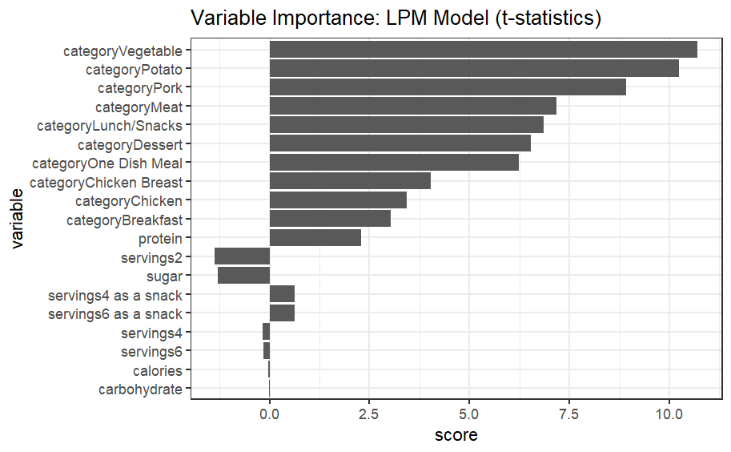

#### -Logit model

```r
logit_summary <- summary(logit_model) # get t-statistic

logit_varimp <- tibble(
  variable = rownames(logit_summary$coefficients[-1, ]),
  score = logit_summary$coefficients[-1, 3]
) %>%
  arrange(desc(abs(score))) %>%
  mutate(variable = factor(variable, levels = variable[order(abs(score))]))
logit_varimp
```

| variable | score |
| --- | --- |
| categoryPotato | 5.9187890104 |
| categoryPork | 5.6403456701 |
| categoryVegetable | 5.4999332768 |
| categoryMeat | 4.7017314680 |
| categoryLunch/Snacks | 4.6023608701 |
| categoryDessert | 4.5381788245 |
| categoryOne Dish Meal | 4.3683965233 |
| categoryChicken Breast | 3.1648936116 |
| categoryChicken | 2.9144774001 |
| categoryBreakfast | 2.7215588800 |

[output cut: 9 more lines]

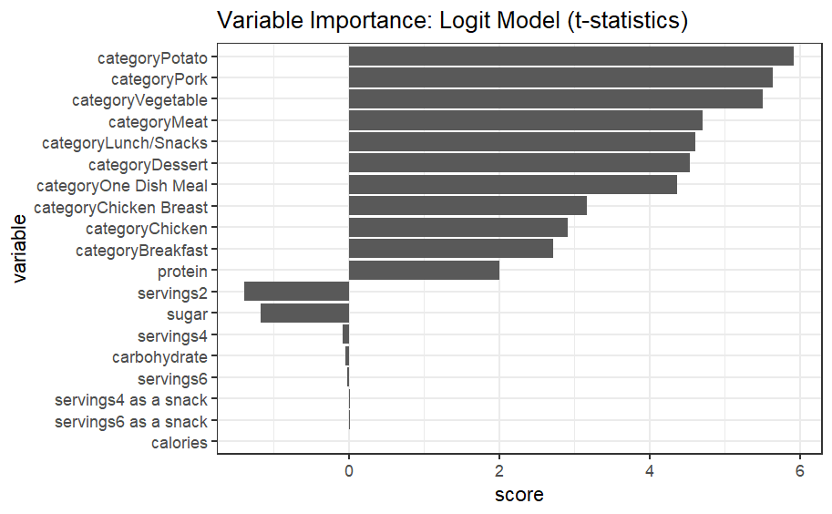

## 5- Estimate of a Random Forest (RF) model.

```r
# Converting the high_traffic variable to a factor
traffic_train$high_traffic <- as.factor(traffic_train$high_traffic)
traffic_test$high_traffic <- as.factor(traffic_test$high_traffic)


# Detection of the number of available cores
cores <- parallel::detectCores()
```

### a- Model construction with ranger

```r
rf_model <- ranger::ranger(model , data=traffic_train, mtry=3,
                         num.threads = cores,
                         importance="impurity",probability = TRUE)
```

### b- Model training

```r
# Hyperparameter grid for research
myGrid <- expand.grid(mtry = 2:6,
                      splitrule = "gini",
                      min.node.size = 1) # Minimal node size; default 1 for classification

metric <- "Accuracy"  # AUC not available
set.seed(345)

# for speed: use `ranger` in parallel mode
rf_model_cv <- train(model, data=traffic_train, method="ranger",
                   metric=metric, trControl=control,
                   tuneGrid = myGrid, num.threads = cores)
```

```r
print(rf_model_cv)
```

```
Random Forest

537 samples
  6 predictor
  2 classes: '0', '1'

No pre-processing
Resampling: Cross-Validated (10 fold)
Summary of sample sizes: 484, 483, 483, 484, 483, 483, ...
Resampling results across tuning parameters:

  mtry  Accuracy   Kappa
  2     0.7112992  0.3485323
  3     0.7225138  0.4009750
  4     0.7262201  0.4121603
  5     0.7114364  0.3825710
  6     0.7150378  0.3894783

Tuning parameter 'splitrule' was held constant at a value of gini

Tuning parameter 'min.node.size' was held constant at a value of 1
Accuracy was used to select the optimal model using the largest value.
The final values used for the model were mtry = 4, splitrule = gini
 and min.node.size = 1.
```

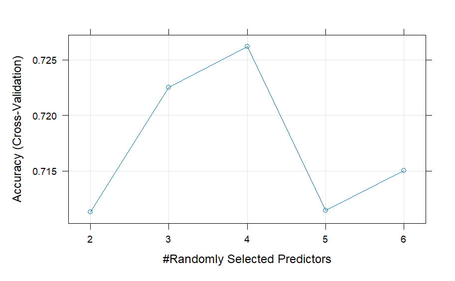

```r
plot(rf_model_cv)
```

```r
rf_model_cv$resample
```

| Accuracy | Kappa | Resample |
| --- | --- | --- |
| 0.7407407 | 0.4246575 | Fold03 |
| 0.6792453 | 0.3106350 | Fold08 |
| 0.7090909 | 0.3723252 | Fold09 |
| 0.7735849 | 0.4984227 | Fold04 |
| 0.7222222 | 0.4104803 | Fold06 |
| 0.7358491 | 0.4378788 | Fold01 |
| 0.7407407 | 0.4449339 | Fold02 |
| 0.6851852 | 0.3433476 | Fold10 |
| 0.7962963 | 0.5822785 | Fold05 |
| 0.6792453 | 0.2966432 | Fold07 |

```r
rf_model_cv$bestTune
```

|  | mtry | splitrule | min.node.size |
| --- | --- | --- | --- |
| 3 | 4 | gini | 1 |

```r
rf_model_cv$finalModel
```

```
Ranger result

Call:
 ranger::ranger(dependent.variable.name = ".outcome", data = x,      mtry = min(param$mtry, ncol(x)), min.node.size = param$min.node.size,      splitrule = as.character(param$splitrule), write.forest = TRUE,      probability = classProbs, ...)

Type:                             Classification
Number of trees:                  500
Sample size:                      537
Number of independent variables:  19
Mtry:                             4
Target node size:                 1
Variable importance mode:         none
Splitrule:                        gini
OOB prediction error:             27.75 %
```

### c- Adjust the model as best as possible

```r
# fit the best RF model (in terms of CV performance) to train data
set.seed(345)
rf_model_1 <- ranger::ranger(model, data=traffic_train, mtry=rf_model_cv$bestTune$mtry,
                          importance="impurity",probability = TRUE)

print(rf_model_1)
```

```
Ranger result

Call:
 ranger::ranger(model, data = traffic_train, mtry = rf_model_cv$bestTune$mtry,      importance = "impurity", probability = TRUE)

Type:                             Probability estimation
Number of trees:                  500
Sample size:                      537
Number of independent variables:  6
Mtry:                             4
Target node size:                 10
Variable importance mode:         impurity
Splitrule:                        gini
OOB prediction error (Brier s.):  0.1802924
```

### d- Variable importance

```r
rf_varimp <- tibble(Variable=names(rf_model_1$variable.importance),
                 Importance = rf_model_1$variable.importance) %>%
  arrange(desc(Importance)) %>%
  mutate(Variable=factor(Variable, levels=Variable[order(Importance)]))
print(rf_varimp)
```

| Variable | Importance |
| --- | --- |
| category | 77.878398 |
| protein | 38.104377 |
| calories | 31.593135 |
| sugar | 28.852158 |
| carbohydrate | 25.502414 |
| servings | 6.759421 |

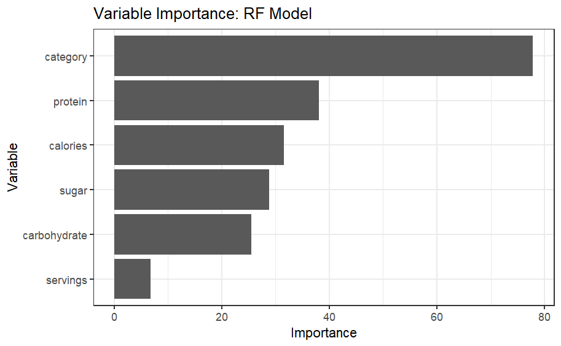

```r
#visualisation
ggplot(rf_varimp, aes(x = Variable, y = Importance)) +
  geom_col() +
  coord_flip() +
  theme_bw() +
  ggtitle("Variable Importance: RF Model")
```

The graph shows the importance of different variables in a RF regression model. The variables category is the best predictors for the high traffic. Then we have the variables Protein, Calories, Sugar and Carbohydrate which contribute moderately in the prediction and finally the variable Servings which is a weak predictor.

## 6- Prediction and comparison of model performance (LPM, Logit, RF)

### a- Predictions

#### - LPM model

```r
lpm_predictions <- predict(lpm_model, newdata = traffic_test, type = "response")

lpm_pred_class <- ifelse(lpm_predictions > 0.5, 1, 0)
```

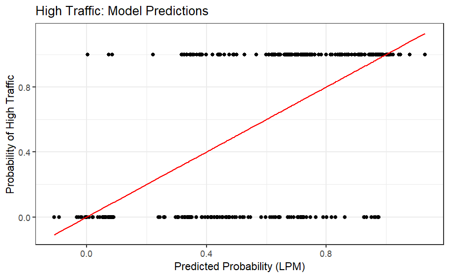

```r
traffic_test <- traffic_test %>%
  mutate(lpm_predictions = predict(lpm_model, newdata = traffic_test))

traffic_test %>%
  ggplot(aes(x = lpm_predictions, y = as.numeric(as.character(high_traffic)))) +
  geom_point() +
  geom_line(aes(y = lpm_predictions), col = "red") +
  labs(x = "Predicted Probability (LPM)", y = "Probability of High Traffic",
       title = "High Traffic: Model Predictions") +
  theme_bw()
```

#### - Logit model

```r
logit_predictions <- predict(logit_model, newdata = traffic_test, type = "response")

logit_pred_class <- ifelse(logit_predictions > 0.5, 1, 0)
```

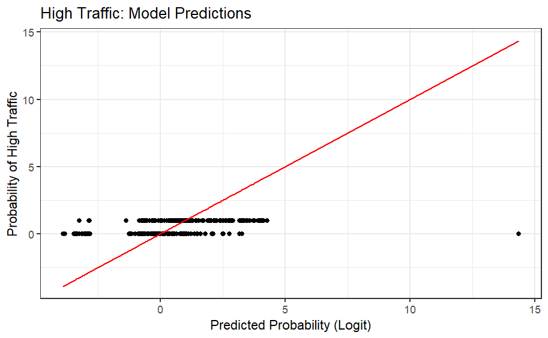

```r
traffic_test <- traffic_test %>%
  mutate(logit_predictions = predict(logit_model, newdata = traffic_test))

traffic_test %>%
  ggplot(aes(x = logit_predictions, y = as.numeric(as.character(high_traffic)))) +
  geom_point() +
  geom_line(aes(y = logit_predictions), col = "red") +
  labs(x = "Predicted Probability (Logit)", y = "Probability of High Traffic",
       title = "High Traffic: Model Predictions") +
  theme_bw()
```

#### - RF model

```r
rf_predictions <- predict(rf_model_1, data = traffic_test, type = "response")$predictions[, 2]
rf_pred_class <- ifelse(rf_predictions >= 0.5, 1, 0)
```

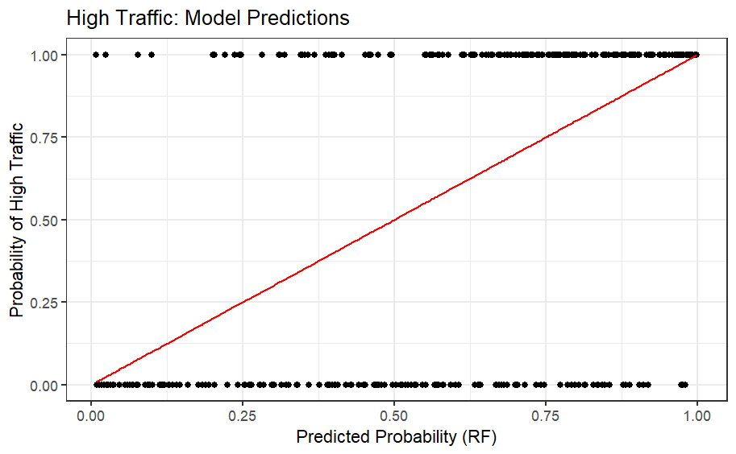

```r
traffic_test <- traffic_test %>%
  mutate(rf_predictions = predict(rf_model_1, data = traffic_test)$predictions[, 2])

traffic_test %>%
  ggplot(aes(x = rf_predictions, y = as.numeric(as.character(high_traffic)))) +
  geom_point() +
  geom_line(aes(y = rf_predictions), col = "red") +
  labs(x = "Predicted Probability (RF)", y = "Probability of High Traffic",
       title = "High Traffic: Model Predictions") +
  theme_bw()
```

### b- Comparaisson of models

#### - Confusion Matrices

**Manual calculation of the confusion matrix for the three models**

- LPM model

```r
cm_lpm <- table(factor(lpm_pred_class), factor(traffic_test$high_traffic),
                dnn=c("prediction","truth"))
prop.table(cm_lpm,margin =1)
```

```
          truth
prediction         0         1
         0 0.7555556 0.2444444
         1 0.2331839 0.7668161
```

```r
cat("accuracy: ", (cm_lpm[1,1] + cm_lpm[2,2]) / sum(cm_lpm), "\n")
```

```
accuracy:  0.7625698
```

- Logit model

```r
cm_logit <- table(factor(logit_pred_class), factor(traffic_test$high_traffic),
                dnn=c("prediction","truth"))
prop.table(cm_logit,margin =1)
```

```
          truth
prediction         0         1
         0 0.7593985 0.2406015
         1 0.2355556 0.7644444
```

```r
cat("accuracy: ", (cm_logit[1,1] + cm_logit[2,2]) / sum(cm_logit), "\n")
```

```
accuracy:  0.7625698
```

- RF model

```r
cm_rf <- table(factor(rf_pred_class), factor(traffic_test$high_traffic),
                dnn=c("prediction","truth"))
prop.table(cm_rf,margin =1)
```

```
          truth
prediction         0         1
         0 0.7286822 0.2713178
         1 0.2620087 0.7379913
```

```r
cat("accuracy: ", (cm_rf[1,1] + cm_rf[2,2]) / sum(cm_rf), "\n")
```

```
accuracy:  0.7346369
```

**Confusion matrix and statistics**

- LPM model

```r
# Confusion matrix for LPM
conf_matrix_lpm <- confusionMatrix(as.factor(lpm_pred_class), as.factor(traffic_test$high_traffic))
print(conf_matrix_lpm)
```

```
Confusion Matrix and Statistics

          Reference
Prediction   0   1
         0 102  33
         1  52 171

               Accuracy : 0.7626
                 95% CI : (0.715, 0.8057)
    No Information Rate : 0.5698
    P-Value [Acc > NIR] : 2.073e-14

                  Kappa : 0.5083

 Mcnemar's Test P-Value : 0.05089

            Sensitivity : 0.6623
            Specificity : 0.8382
         Pos Pred Value : 0.7556
         Neg Pred Value : 0.7668
             Prevalence : 0.4302
         Detection Rate : 0.2849
   Detection Prevalence : 0.3771
      Balanced Accuracy : 0.7503

       'Positive' Class : 0
```

- Logit model

```r
# Confusion matrix for Logit
conf_matrix_logit <- confusionMatrix(as.factor(logit_pred_class), as.factor(traffic_test$high_traffic))
print(conf_matrix_logit)
```

```
Confusion Matrix and Statistics

          Reference
Prediction   0   1
         0 101  32
         1  53 172

               Accuracy : 0.7626
                 95% CI : (0.715, 0.8057)
    No Information Rate : 0.5698
    P-Value [Acc > NIR] : 2.073e-14

                  Kappa : 0.5075

 Mcnemar's Test P-Value : 0.03006

            Sensitivity : 0.6558
            Specificity : 0.8431
         Pos Pred Value : 0.7594
         Neg Pred Value : 0.7644
             Prevalence : 0.4302
         Detection Rate : 0.2821
   Detection Prevalence : 0.3715
      Balanced Accuracy : 0.7495

       'Positive' Class : 0
```

- RF model

```r
# Confusion matrix for RF
conf_matrix_rf <- confusionMatrix(as.factor(rf_pred_class), as.factor(traffic_test$high_traffic))
print(conf_matrix_rf)
```

```
Confusion Matrix and Statistics

          Reference
Prediction   0   1
         0  94  35
         1  60 169

               Accuracy : 0.7346
                 95% CI : (0.6857, 0.7797)
    No Information Rate : 0.5698
    P-Value [Acc > NIR] : 7.414e-11

                  Kappa : 0.4477

 Mcnemar's Test P-Value : 0.0138

            Sensitivity : 0.6104
            Specificity : 0.8284
         Pos Pred Value : 0.7287
         Neg Pred Value : 0.7380
             Prevalence : 0.4302
         Detection Rate : 0.2626
   Detection Prevalence : 0.3603
      Balanced Accuracy : 0.7194

       'Positive' Class : 0
```

#### - ROCs et AUC

```r
# ROC and AUC curve for LPM
roc_lpm <- roc(traffic_test$high_traffic, lpm_predictions)
auc_lpm <- auc(roc_lpm)

# ROC and AUC curve for Logit
roc_logit <- roc(traffic_test$high_traffic, logit_predictions)
auc_logit <- auc(roc_logit)

# ROC and AUC curve for RF
roc_rf <- roc(traffic_test$high_traffic, rf_predictions)
auc_rf <- auc(roc_rf)
```

```r
#Compare AUC (Area Under Curve)
print(paste("AUC LPM :", auc_lpm))
```

```
[1] "AUC LPM : 0.826967150496562"
```

```r
print(paste("AUC Logit :", auc_logit))
```

```
[1] "AUC Logit : 0.824548001018589"
```

```r
print(paste("AUC RF :", auc_rf))
```

```
[1] "AUC RF : 0.798223834988541"
```

```r
# Plotting ROC curves
plot(roc_lpm, col = "blue", main = "Courbes ROC des modèles")
lines(roc_logit, col = "green")
```

[figure not shown]

```r
lines(roc_rf, col = "red")
legend("bottomright", legend = c("LPM (AUC = 0.827)", "Logit (AUC = 0.825)", "RF (AUC = 0.798)"),
       col = c("blue", "green", "red"), lty = 1)
```

This graph illustrates the performance of the three models (LPM, Logit, RF) in terms of their ability to correctly distinguish between positive and negative classes. The ROC curve shows the relationship between the true positive rate (sensitivity) and the false positive rate at different decision thresholds. AUC (Area Under the Curve) is a metric that quantifies this performance, with an AUC closer to 1 indicating better performance.

LPM (AUC = 0.827): The LPM model has a very good discriminating ability, with an AUC of 0.827, which is slightly higher than the other models. Logit (AUC = 0.825): The Logit model is almost equivalent to the LPM with an AUC of 0.825, which shows that it also performs very well. RF (AUC = 0.798): The RF model has a slightly lower performance with an AUC of 0.798, although it remains competitive.

### c- Model selection

#### - Summary of results for the Performance of Modèls

[output not shown]

#### - Choice of model

If the goal is only to optimize performance (AUC), LPM can be considered, but Logit remains a more robust and interpretable choice. RF can be ruled out due to its slightly lower performance.

So, the Logit is therefore our preferred choice for its robustness and interpretability. Using its results, it is possible to identify the levers for improvement for site traffic, while implementing concrete solutions to optimize the user experience and marketing campaigns.

we choose the **Logit model** for three reasons:

- Balanced performance:Logit is almost equivalent to LPM in terms of Accuracy and AUC, but offers better specificity (84.31%) and a small difference in sensitivity (65.58%).
- Interpretability:Logit is easy to interpret, which is crucial for understanding the factors contributing to high traffic.
- Stability:The logit model is less sensitive to problems related to linear assumptions (as in LPM) and more reliable when probabilities are needed.

## 7- Interpretation of the chosen model

### a- Interpretation of estimate model

The logit model estimates the probability that a revenue will have high traffic based on the explanatory variables.

```r
logit_model <- glm(model, data = traffic_train, family="binomial")

stargazer(logit_model, type = "text", title = "Résult of the regression model",
          align = TRUE, digits = 3,
          column.labels=c("LOGIT"),
          header=FALSE,
          dep.var.caption="",dep.var.labels="",
          omit.table.layout = "n", star.cutoffs = NA,no.space=TRUE,
          keep.stat=c("rsq","n"))
```

```
Résult of the regression model
================================

                         LOGIT
--------------------------------
categoryBreakfast        2.118
                        (0.778)
categoryChicken          2.343
                        (0.804)
categoryChicken Breast   2.510
                        (0.793)
categoryDessert          3.760
                        (0.829)
categoryLunch/Snacks     3.747
                        (0.814)
categoryMeat             3.851
                        (0.819)
categoryOne Dish Meal    3.670
                        (0.840)
categoryPork             5.137
                        (0.911)
categoryPotato           6.112
                        (1.033)
categoryVegetable        6.867
                        (1.248)
calories                0.00000
                       (0.0003)
carbohydrate            -0.0001
                        (0.003)
sugar                   -0.010
                        (0.009)
protein                  0.007
                        (0.004)
servings2               -0.489
                        (0.352)
servings4               -0.025
                        (0.310)
servings4 as a snack    13.485
                       (882.744)
servings6               -0.006
                        (0.356)
servings6 as a snack    13.483
                       (882.744)
Constant                -2.820
                        (0.766)
--------------------------------
Observations              537
================================
```

The estimated coefficients of the Logit model make it possible to identify the characteristics that have the greatest impact on traffic.

The absence of **categoryBeverages** and **servings1** in the model estimation results is explained by the fact that they are considered as reference categories for the variables **category** and **servings** respectively, which are categorical variables due to the presence of the constant in the estimate in order to avoid multicollinearity problems in the model.

The coefficient of the variables “categoryBreakfast”, “categoryChicken”, “categoryChicken Breast”, “categoryDessert”, “categoryLunch/Snacks”, “categoryMeat”, “categoryOne Dish Meal”, “categoryPork”, “categoryPotato”, “categoryVegetable”, “protein”, “calories”, “servings4 as a snack”, “servings6 as a snack” is of positive sign and therefore these variables positively influence the probability of having a high traffic for recipes.

In addition, the coefficient of the variables “carbohydrate”, “sugar”, “servings2”, “servings4” and “servings6” is negative and therefore these variables negatively influence the probability of having high traffic for recipes.

#### **Categorical variables (“category” and “servings”)**

**Variable “categorie”**

- **categoryBreakfast**

- **categoryChicken**

- **categoryChicken Breast**

- **categoryDessert**

- **categoryLunch/Snacks**

- **categoryMeat**

- **categoryOne Dish Meal**

- **categoryPork**

- **categoryPotato**

- **categoryVegetable**

**Variable “servings”**

- **servings2**

coeff = -0.489: This means that there is 0.489 times less chance that servings2 for revenue will result in high traffic compared to servings1.

- **servings4**

coeff = -0.025 : This means that there is 0.025 times less chance that servings4 for revenue will result in high traffic compared to servings1.

- **servings4 as a snack**

coeff = 13.485 : This means that there is 13,485 times more chance that servings4 as a snack for the recipe will result in high traffic compared to servings1.

- **servings6**

coeff = -0.006 : This means that there is -0.006 times less chance that servings6 for revenue will result in high traffic compared to servings1.

- **servings6 as a snack**

coeff = 13.483 : This means that there is 13.483 times more chance that servings6 as a snack for the recipe will result in high traffic compared to servings1.

#### **Variable numériques (“calories”, “carbohydrate”, “sugar” et “protein”)**

- **calories**

- **carbohydrate**

- **sugar**

coeff = -0.010: This means that recipes with sugar are 0.010 times less likely to have high traffic.

- **protein**

coeff = 0.007: This means that recipes with protein are 0.007 times more likely to have high traffic.

### b- Interpretation of Prédiction result

- Logit Model:

**Accuracy (Global Precision) : 76.26%**

This means that 76.26% of the model’s predictions are correct, whether for observations with high or low traffic. In addition, the accuracy is identical to that of the Linear Probability Model (LPM), which indicates a similar performance in this aspect. High overall accuracy.

**Kappa : 0.5075**

The Kappa statistic evaluates the agreement between predictions and observed values by taking into account chance. And so, a value of 0.5075 indicates moderate agreement (according to the Landis and Koch scale: between 0.41 and 0.60 corresponds to moderate agreement). This shows that the model is able to predict better than chance, but there is still room for improvement.

**Sensitivity (Recall, Positive true rates) : 65.58%**

**Specificity (Negative true rate) : 84.31%**

**AUC (Area Under the Curve) : 0.825**

The AUC measures the model’s ability to correctly distinguish between positive cases (high traffic) and negative cases (low traffic). And so, a value of 0.825 indicates a very good discriminating ability (an AUC between 0.8 and 0.9 is considered excellent). This means that the model performs well at differentiating between high- and low-traffic observations, but remains slightly below the LPM (AUC = 0.827).

### c- Validation of model

From all of the above, we can therefore conclude that the model is good.

### d- Reconmmandation for more higher traffic

Strategic improvements on popular categories, the creation of targeted content, and the engagement of visitors through a better user experience and targeted marketing will allow for higher traffic.